# 探索自我觉察与沟通

林闻正|Lin Wenzheng

## 你是如何构建自己的社交媒体形象的

- 你使用的社交媒体有哪些
  - 微信、微博、小红书、抖音、知乎……
  - 你选择了哪个平台，为什么？
  - 你想让谁看到你的帖子？谁会对它回应？
  - 你如何看待这些回应？
  - 你在社交媒体上发布什么样的照片？

[figure not shown]

[figure not shown]

## 自我觉察

> 自我觉察是自我认识、自我理解和自我表露的关键。与他人坦诚相对的关键是先了解自己是谁、你的本质是什么样子。要表露自己的感受和反应，首先必须觉察到它们。

> 大卫·约翰逊（David Johnson）

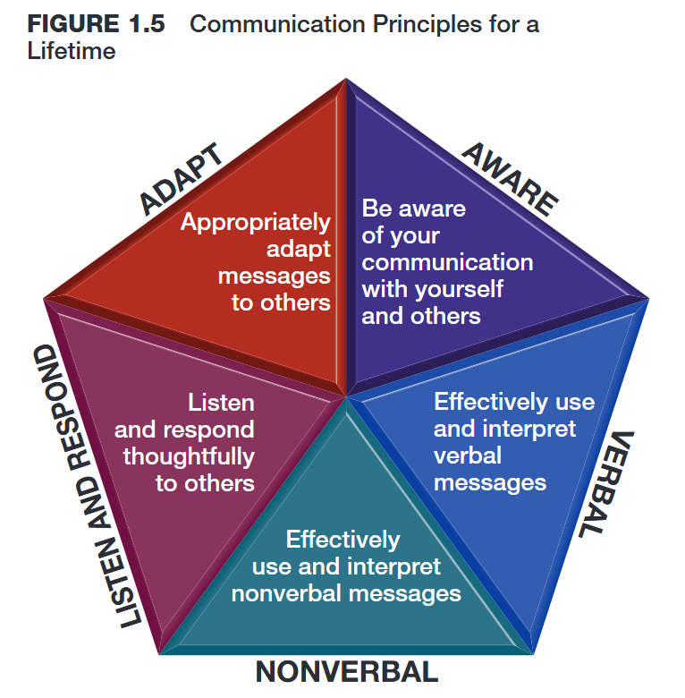

> There are three things extremely hard: steel, a diamond, and to know oneself.

> 有三样东西极为‘坚’难：钢铁、钻石和认识自己。

> 本杰明·富兰克林（Benjamin Franklin）
- 认识自己是一个终生的过程

## 什么是自我觉察

- 一个自我觉察的定义是“观察和反思自己的心理状态的能力。”
- 还有一种与之相关的观点认为，自我觉察有时可以称为象征性自我觉察，是人类独有的表征自己的能力，这种表征可以通过语言用于与他人沟通
- 高度自我觉察的人更能预测他人对自己的看法，换位思考，并进行共情沟通
  - 亚伯拉罕·马斯洛（Abraham Maslow）
  - 1.*无意识的低竞争力*。
  - 2. *有意识的低竞争力*。
  - 3. *有意识的竞争力*。
  - 4.*无意识的竞争力*。

## 自我概念：你是谁

- 你是谁？
- 心理学家卡伦·霍尼（Karen Horney）：**自我**是“所有人类共同拥有的，但每个人都独一无二的核心的内在力量，它是成长的深层源泉。”
- 自我概念：你的内在身份认同或主观角度对你自己是谁的描述
  - 你的态度：习得的对于一个人、物体或观念以有利或不利的方式做出反应的倾向
  - 信念：你对现实进行理解的心理结构——什么是真实的、什么是虚假的
  - 价值观：对好与坏、正确或错误的持久观点